# Nutritional application data cleaning

## Loading libraries

Disclaimer: This notebook uses missingo python library for a very nice way to visualize the distribution of NaN values.  
Missingno is a Python library and compatible with Pandas.  
To solved the ModuleNotFoundError install the libary using Anaconda prompt with the following command:

`conda install -c conda-forge/label/gcc7 missingno`

```python
import numpy as np
import pandas as pd
import matplotlib.pyplot as plt
import seaborn as sns
import warnings
warnings.filterwarnings("ignore")
import missingno as msno
plt.style.use('fivethirtyeight')
```

## Loading data

Origin: https://us.openfoodfacts.org/data

```python
df = pd.read_csv("data/en.openfoodfacts.org.products.csv",sep="\t",encoding='utf8')
```

```python
df.shape
```

```
(2573572, 186)
```

## Cleaning data

### Handling dublicate records

```python
startinglength = df.shape[0];
duplicates = df.duplicated()
len(df[duplicates])
```

```
3
```

```python
data=df.drop_duplicates()
duplicates = df.duplicated(subset = "code")
len(df[duplicates])
```

```
338
```

```python
duplicates2 = data.duplicated(subset = "code")
len(data[duplicates])
```

```
335
```

The 'code column' is an indentifier for the products, currently we have 338 dublicates. I belive dropping them early will be beficial for further actions.

```python
df = df.drop_duplicates(subset = "code")
```

```python
data = data.drop_duplicates(subset = "code")
```

```python
data.head(10)
```

|  | code | url | creator | created_t | created_datetime | last_modified_t | last_modified_datetime | product_name | abbreviated_product_name | generic_name | ... | carbon-footprint-from-meat-or-fish_100g | nutrition-score-fr_100g | nutrition-score-uk_100g | glycemic-index_100g | water-hardness_100g | choline_100g | phylloquinone_100g | beta-glucan_100g | inositol_100g | carnitine_100g |
| --- | --- | --- | --- | --- | --- | --- | --- | --- | --- | --- | --- | --- | --- | --- | --- | --- | --- | --- | --- | --- | --- |
| 0 | 00000000000000225 | http://world-en.openfoodfacts.org/product/0000... | nutrinet-sante | 1623855208 | 2021-06-16T14:53:28Z | 1623855209 | 2021-06-16T14:53:29Z | jeunes pousses | NaN | NaN | ... | NaN | NaN | NaN | NaN | NaN | NaN | NaN | NaN | NaN | NaN |
| 1 | 0000000000000207025004 | http://world-en.openfoodfacts.org/product/0000... | kiliweb | 1656948610 | 2022-07-04T15:30:10Z | 1656948613 | 2022-07-04T15:30:13Z | Andrè | NaN | NaN | ... | NaN | NaN | NaN | NaN | NaN | NaN | NaN | NaN | NaN | NaN |
| 2 | 00000000000003429145 | http://world-en.openfoodfacts.org/product/0000... | kiliweb | 1630483911 | 2021-09-01T08:11:51Z | 1656488106 | 2022-06-29T07:35:06Z | L.casei | NaN | NaN | ... | NaN | NaN | NaN | NaN | NaN | NaN | NaN | NaN | NaN | NaN |
| 3 | 00000000000026772226 | http://world-en.openfoodfacts.org/product/0000... | kiliweb | 1654250311 | 2022-06-03T09:58:31Z | 1654270474 | 2022-06-03T15:34:34Z | Skyr | NaN | NaN | ... | NaN | -5.0 | NaN | NaN | NaN | NaN | NaN | NaN | NaN | NaN |
| 4 | 0000000000017 | http://world-en.openfoodfacts.org/product/0000... | kiliweb | 1529059080 | 2018-06-15T10:38:00Z | 1561463718 | 2019-06-25T11:55:18Z | Vitória crackers | NaN | NaN | ... | NaN | NaN | NaN | NaN | NaN | NaN | NaN | NaN | NaN | NaN |
| 5 | 0000000000031 | http://world-en.openfoodfacts.org/product/0000... | isagoofy | 1539464774 | 2018-10-13T21:06:14Z | 1539464817 | 2018-10-13T21:06:57Z | Cacao | NaN | NaN | ... | NaN | NaN | NaN | NaN | NaN | NaN | NaN | NaN | NaN | NaN |
| 6 | 000000000003327986 | http://world-en.openfoodfacts.org/product/0000... | kiliweb | 1574175736 | 2019-11-19T15:02:16Z | 1624390765 | 2021-06-22T19:39:25Z | Filetes de pollo empanado | NaN | NaN | ... | NaN | NaN | NaN | NaN | NaN | NaN | NaN | NaN | NaN | NaN |
| 7 | 000000000004128579 | http://world-en.openfoodfacts.org/product/0000... | kiliweb | 1649449251 | 2022-04-08T20:20:51Z | 1649449920 | 2022-04-08T20:32:00Z | Burger Meat Pollo | NaN | NaN | ... | NaN | NaN | NaN | NaN | NaN | NaN | NaN | NaN | NaN | NaN |
| 8 | 000000000004622327 | http://world-en.openfoodfacts.org/product/0000... | kiliweb | 1619501895 | 2021-04-27T05:38:15Z | 1619501897 | 2021-04-27T05:38:17Z | Hamburguesas de ternera 100% | NaN | NaN | ... | NaN | NaN | NaN | NaN | NaN | NaN | NaN | NaN | NaN | NaN |
| 9 | 00000000001 | http://world-en.openfoodfacts.org/product/0000... | inf | 1634745456 | 2021-10-20T15:57:36Z | 1634745530 | 2021-10-20T15:58:50Z | hyde icon | NaN | NaN | ... | NaN | NaN | NaN | NaN | NaN | NaN | NaN | NaN | NaN | NaN |

10 rows × 186 columns

### Fixing iregularities and cleaning for the important futures

Firstly, I want to clean the product name and brands

```python
col_pname = data.filter(regex=("name")).columns
col_pname
```

```
Index(['product_name', 'abbreviated_product_name', 'generic_name'], dtype='object')
```

```python
for col in col_pname :
  data[col] = data[col].str.lower()
data[col_pname]
```

|  | product_name | abbreviated_product_name | generic_name |
| --- | --- | --- | --- |
| 0 | jeunes pousses | NaN | NaN |
| 1 | andrè | NaN | NaN |
| 2 | l.casei | NaN | NaN |
| 3 | skyr | NaN | NaN |
| 4 | vitória crackers | NaN | NaN |
| ... | ... | ... | ... |
| 2573567 | sandwich club rillette poisson combava | NaN | NaN |
| 2573568 | thé noir bio darjeeling | NaN | NaN |
| 2573569 | fati | NaN | NaN |
| 2573570 | light & free skyr a boire | NaN | NaN |
| 2573571 | signal toothpaste | NaN | NaN |

2573234 rows × 3 columns

```python
products = pd.DataFrame(data[col_pname].isna().sum()).sort_values(by=[0])
to_drop_products = products.index.values[1:]
to_drop_products
data = data.drop(to_drop_products, axis = 1)
data["product_name"].isna().sum() / len(data)
```

```
0.03557779821034542
```

Seems like 3% of the products do not have a name, considering that the percentage is rather low I will drop those records

```python
data.dropna(subset=['product_name'],inplace= True)
data["product_name"].isna().sum() / len(data)
```

```
0.0
```

```python
data.brands = data.brands.str.lower()
data.brands_tags = data.brands_tags.str.lower()
brands = pd.DataFrame(data[["brands","brands_tags"]].isna().sum()).sort_values(by=[0])
to_drop_brands = brands.index.values[1]

data = data.drop(to_drop_brands, axis = 1)
```

```python
data.brands
```

```
0          endives
1              NaN
2              NaN
3           danone
4              NaN
            ...
2573567        NaN
2573568      pagès
2573569        NaN
2573570        NaN
2573571        NaN
Name: brands, Length: 2481684, dtype: object
```

```python
data["brands"].isna().sum() / len(data)
```

```
0.507858373588257
```

```python
data.shape
```

```
(2481684, 183)
```

Now this seems tricky, unlike the products name, around 50% of the brands are missing, I belive dropping all those rows would be a big waste, so I will replace the NaN values with Unknown for the moment.

```python
data["brands"] = data["brands"].fillna('unknown')
data["brands"].isna().sum() / len(data)
```

```
0.0
```

Removing unused features

```python
var = data.shape[1]

to_drop = ["energy_" , "carbon","fruits","collagen","glycemic","water"]

for i in to_drop:
    col_name = data.filter(regex=(i)).columns
    data = data.drop(col_name, axis = 1)

print("Nr of dropped columns: "+ str(var - data.shape[1]))
```

```
Nr of dropped columns: 11
```

Tackling missing values from the macro-nutrients

```python
col_nutrition = data.filter(regex=("100g")).columns
data[col_nutrition].isna().sum()
```

```
energy-kj_100g          2300998
energy-kcal_100g         492225
energy-from-fat_100g    2480708
fat_100g                 457936
saturated-fat_100g       498228
                         ...
choline_100g            2481598
phylloquinone_100g      2479974
beta-glucan_100g        2481636
inositol_100g           2481606
carnitine_100g          2481639
Length: 101, dtype: int64
```

```python
na_viz1=pd.DataFrame(data[col_nutrition].isna().sum())
na_viz1=na_viz1[na_viz1[0]!=0]
print(len(na_viz1))
```

```
101
```

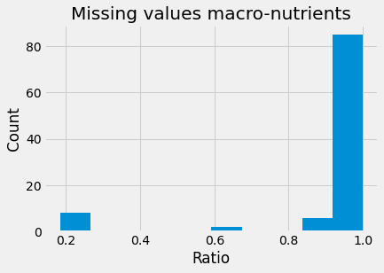

```python
na_viz1["ratio"] = na_viz1[0]/len(data)
na_viz1["ratio"].hist()
plt.title("Missing values macro-nutrients")
plt.xlabel('Ratio')
plt.ylabel('Count')
plt.show()
```

```python
na_list = na_viz1[na_viz1["ratio"]>=0.5].index
na_list
```

```
Index(['energy-kj_100g', 'energy-from-fat_100g', '-butyric-acid_100g',
       '-caproic-acid_100g', '-caprylic-acid_100g', '-capric-acid_100g',
       '-lauric-acid_100g', '-myristic-acid_100g', '-palmitic-acid_100g',
       '-stearic-acid_100g', '-arachidic-acid_100g', '-behenic-acid_100g',
       '-lignoceric-acid_100g', '-cerotic-acid_100g', '-montanic-acid_100g',
       '-melissic-acid_100g', 'monounsaturated-fat_100g',
       'polyunsaturated-fat_100g', 'omega-3-fat_100g',
       '-alpha-linolenic-acid_100g', '-eicosapentaenoic-acid_100g',
       '-docosahexaenoic-acid_100g', 'omega-6-fat_100g', '-linoleic-acid_100g',
       '-arachidonic-acid_100g', '-gamma-linolenic-acid_100g',
       '-dihomo-gamma-linolenic-acid_100g', 'omega-9-fat_100g',
       '-oleic-acid_100g', '-elaidic-acid_100g', '-gondoic-acid_100g',
       '-mead-acid_100g', '-erucic-acid_100g', '-nervonic-acid_100g',
       'trans-fat_100g', 'cholesterol_100g', '-sucrose_100g', '-glucose_100g',
       '-fructose_100g', '-lactose_100g', '-maltose_100g',
       '-maltodextrins_100g', 'starch_100g', 'polyols_100g', 'fiber_100g',
       'soluble-fiber_100g', 'insoluble-fiber_100g', 'casein_100g',
       'serum-proteins_100g', 'nucleotides_100g', 'alcohol_100g',
       'vitamin-a_100g', 'beta-carotene_100g', 'vitamin-d_100g',
       'vitamin-e_100g', 'vitamin-k_100g', 'vitamin-c_100g', 'vitamin-b1_100g',
       'vitamin-b2_100g', 'vitamin-pp_100g', 'vitamin-b6_100g',
       'vitamin-b9_100g', 'folates_100g', 'vitamin-b12_100g', 'biotin_100g',
       'pantothenic-acid_100g', 'silica_100g', 'potassium_100g',
       'chloride_100g', 'calcium_100g', 'phosphorus_100g', 'iron_100g',
       'magnesium_100g', 'zinc_100g', 'copper_100g', 'manganese_100g',
       'fluoride_100g', 'selenium_100g', 'chromium_100g', 'molybdenum_100g',
       'iodine_100g', 'caffeine_100g', 'taurine_100g', 'ph_100g', 'cocoa_100g',
       'chlorophyl_100g', 'nutrition-score-fr_100g', 'nutrition-score-uk_100g',
       'choline_100g', 'phylloquinone_100g', 'beta-glucan_100g',
       'inositol_100g', 'carnitine_100g'],
      dtype='object')
```

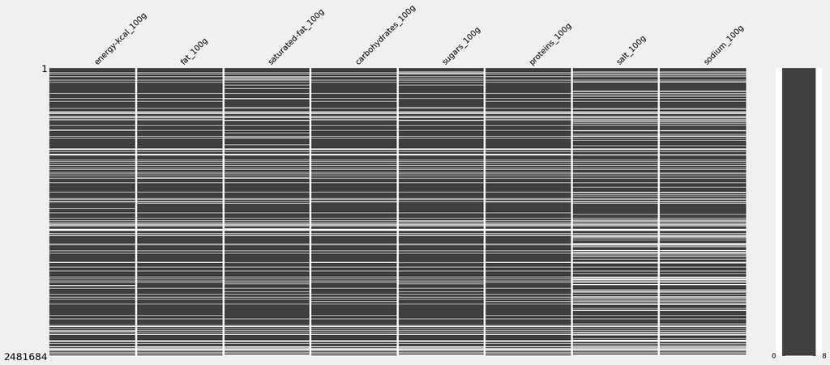

```python
data = data.drop(na_list, axis=1)

col_nutrition = data.filter(regex=("100g")).columns

msno.matrix(data[col_nutrition])
plt.show()
```

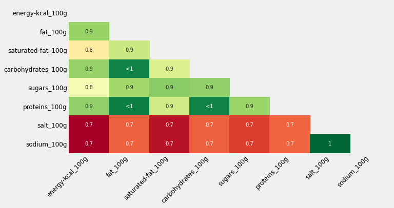

```python
msno.heatmap(data[col_nutrition], cmap="RdYlGn", figsize=(10,5), fontsize=12);
```

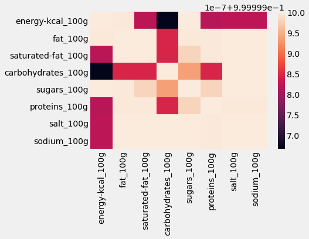

```python
col_nutrition = data.filter(regex=("100g")).columns

# Matrice corrélations
corr_matrix=data[col_nutrition].corr()

sns.heatmap(corr_matrix)
plt.show()
```

```python
data = data.drop("sodium_100g", axis = 1)
```

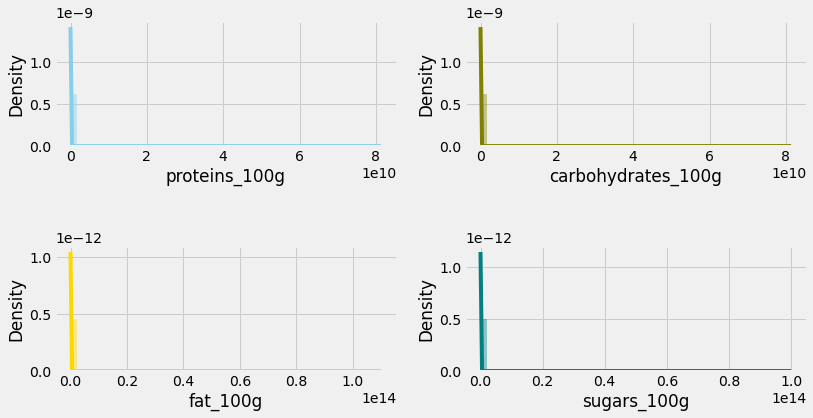

```python
f, axes = plt.subplots(2, 2, figsize=(12, 6))
plt.subplots_adjust(hspace = 0.8)
sns.distplot( data["proteins_100g"] , color="skyblue", ax=axes[0, 0])
sns.distplot( data["carbohydrates_100g"] , color="olive", ax=axes[0, 1])
sns.distplot( data["fat_100g"] , color="gold", ax=axes[1, 0])
sns.distplot( data["sugars_100g"] , color="teal", ax=axes[1, 1])
plt.show()
```

```python
col_nutrition = data.filter(regex=("100g")).columns
for col in data[col_nutrition].columns :
  out_nr = data[(data[col] >= 100)|(data[col] < 0)];
  print(str(len(out_nr)) + " outliers in " + col);
  print(str(len(out_nr)/len(data)*100) + "% of outliers in " + col);
```

```
1496787 outliers in energy-kcal_100g
60.313359799233105% of outliers in energy-kcal_100g
11052 outliers in fat_100g
0.44534275919093647% of outliers in fat_100g
354 outliers in saturated-fat_100g
0.014264507487657575% of outliers in saturated-fat_100g
10199 outliers in carbohydrates_100g
0.4109709374763266% of outliers in carbohydrates_100g
4469 outliers in sugars_100g
0.18007933322695396% of outliers in sugars_100g
659 outliers in proteins_100g
0.026554549249622438% of outliers in proteins_100g
1804 outliers in salt_100g
0.07269257488060527% of outliers in salt_100g
```

```python
val1 = data.shape[0]

index = data[data["sugars_100g"] > data["carbohydrates_100g"] ].index
data.drop(index, inplace=True)

val2 = data.shape[0]

print("Number of dropped product: " + str(val1 - val2))
```

```
Number of dropped product: 3325
```

```python
val1 = data.shape[0]

index = data[data["fat_100g"] < data["saturated-fat_100g"]].index
data.drop(index, inplace=True)

val2 = data.shape[0]

print("Number of dropped product: " + str(val1 - val2))
```

```
Number of dropped product: 1365
```

```python
val1 = data.shape[0]

index = data[data["salt_100g"]  >= 100].index
data.drop(index, inplace=True)

val2 = data.shape[0]
print("Number of dropped product: " + str(val1 - val2))
```

```
Number of dropped product: 1780
```

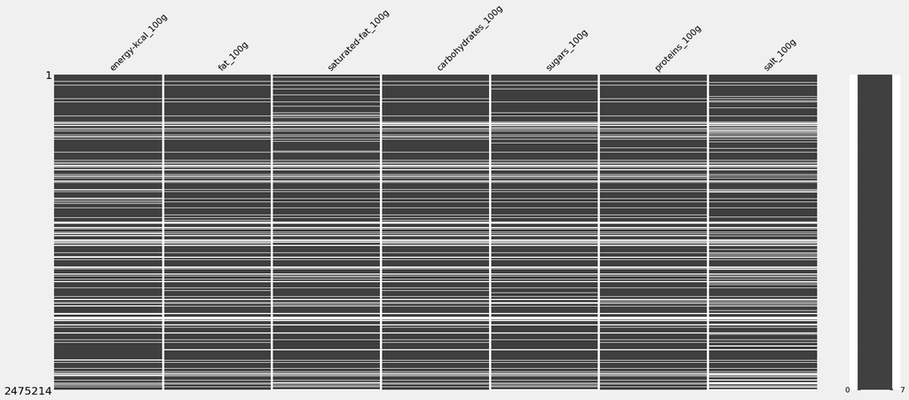

```python
col_nutrition = data.filter(regex=("100g")).columns

msno.matrix(data[col_nutrition])
plt.show()
```

```python
col_pname = data.filter(regex=("name"))
col_pdate = data["created_datetime"]
col_pgrade = data["nutriscore_grade"]
col_pscore = data["nutriscore_score"]
col_pcode = data['code']
data_nutrition = data[col_nutrition]
```

```python
data_nutrition.dropna(axis = 0, thresh=4, inplace = True)
index = data_nutrition.index

keep = col_pname.index.isin(index)
col_pname = col_pname[keep]

keep = col_pdate.index.isin(index)
col_pdate = col_pdate[keep]

keep = col_pgrade.index.isin(index)
col_pgrade = col_pgrade[keep]

keep = col_pscore.index.isin(index)
col_pscore = col_pscore[keep]

keep = col_pcode.index.isin(index)
col_pcode = col_pcode[keep]

data = pd.concat([col_pcode,col_pdate,col_pname,data_nutrition, col_pscore,col_pgrade], axis = 1)
data.head(5)
```

|  | code | created_datetime | product_name | energy-kcal_100g | fat_100g | saturated-fat_100g | carbohydrates_100g | sugars_100g | proteins_100g | salt_100g | nutriscore_score | nutriscore_grade |
| --- | --- | --- | --- | --- | --- | --- | --- | --- | --- | --- | --- | --- |
| 1 | 0000000000000207025004 | 2022-07-04T15:30:10Z | andrè | 165.0 | 2.0 | 2.00 | 65.0 | 12.6 | 1.5 | NaN | NaN | NaN |
| 2 | 00000000000003429145 | 2021-09-01T08:11:51Z | l.casei | NaN | 1.4 | 0.90 | 9.8 | 9.8 | 2.7 | 0.10 | NaN | NaN |
| 3 | 00000000000026772226 | 2022-06-03T09:58:31Z | skyr | 57.0 | 0.2 | 0.10 | 3.9 | 3.9 | 10.0 | 0.09 | -5.0 | a |
| 4 | 0000000000017 | 2018-06-15T10:38:00Z | vitória crackers | 375.0 | 7.0 | 3.08 | 70.1 | 15.0 | 7.8 | 1.40 | NaN | NaN |
| 6 | 000000000003327986 | 2019-11-19T15:02:16Z | filetes de pollo empanado | 163.9 | 1.9 | 1.00 | NaN | NaN | 15.3 | 1.10 | NaN | NaN |

### Filling in missing values

To fill in missing values I am going to use KNNimputer.  
It is a more useful method which works on the basic approach of the KNN algorithm rather than the naive approach of filling all the values with mean or the median.  
In this approach, we specify a distance from the missing values which is also known as the K parameter. The missing value will be predicted in reference to the mean of the neighbours.

```python
from sklearn.impute import KNNImputer

col_nutrition = data.filter(regex=("100g")).columns

X = data[col_nutrition]

# define imputer
imputer = KNNImputer(n_neighbors=5, weights='uniform', metric='nan_euclidean')
```

```python
# fit
imputer.fit(X)
```

```
KNNImputer()
```

```python
# transform
Xtrans = imputer.transform(X)

data_nutrition = pd.DataFrame(Xtrans, columns= col_nutrition)
data_nutrition.head()
```

|  | energy-kcal_100g | fat_100g | saturated-fat_100g | carbohydrates_100g | sugars_100g | proteins_100g | salt_100g |
| --- | --- | --- | --- | --- | --- | --- | --- |
| 0 | 165.0 | 2.0 | 2.00 | 65.000000 | 12.600000 | 1.5 | 0.120764 |
| 1 | 65.8 | 1.4 | 0.90 | 9.800000 | 9.800000 | 2.7 | 0.100000 |
| 2 | 57.0 | 0.2 | 0.10 | 3.900000 | 3.900000 | 10.0 | 0.090000 |
| 3 | 375.0 | 7.0 | 3.08 | 70.100000 | 15.000000 | 7.8 | 1.400000 |
| 4 | 163.9 | 1.9 | 1.00 | 43.965848 | 20.505848 | 15.3 | 1.100000 |

### Building final dataset

```python
col_pname = data.filter(regex=("name")).reset_index(drop = True)
col_pdate = data["created_datetime"].reset_index(drop = True)
col_pgrade = data["nutriscore_grade"].reset_index(drop = True)
col_pscore = data["nutriscore_score"].reset_index(drop = True)
col_pcode = data["code"].reset_index(drop = True)

data_final = pd.concat([col_pcode,col_pdate,col_pname,data_nutrition, col_pscore,col_pgrade], axis = 1)
data_final.head(5)
```

|  | code | created_datetime | product_name | energy-kcal_100g | fat_100g | saturated-fat_100g | carbohydrates_100g | sugars_100g | proteins_100g | salt_100g | nutriscore_score | nutriscore_grade |
| --- | --- | --- | --- | --- | --- | --- | --- | --- | --- | --- | --- | --- |
| 0 | 0000000000000207025004 | 2022-07-04T15:30:10Z | andrè | 165.0 | 2.0 | 2.00 | 65.000000 | 12.600000 | 1.5 | 0.120764 | NaN | NaN |
| 1 | 00000000000003429145 | 2021-09-01T08:11:51Z | l.casei | 65.8 | 1.4 | 0.90 | 9.800000 | 9.800000 | 2.7 | 0.100000 | NaN | NaN |
| 2 | 00000000000026772226 | 2022-06-03T09:58:31Z | skyr | 57.0 | 0.2 | 0.10 | 3.900000 | 3.900000 | 10.0 | 0.090000 | -5.0 | a |
| 3 | 0000000000017 | 2018-06-15T10:38:00Z | vitória crackers | 375.0 | 7.0 | 3.08 | 70.100000 | 15.000000 | 7.8 | 1.400000 | NaN | NaN |
| 4 | 000000000003327986 | 2019-11-19T15:02:16Z | filetes de pollo empanado | 163.9 | 1.9 | 1.00 | 43.965848 | 20.505848 | 15.3 | 1.100000 | NaN | NaN |

```python
val1 = data_final.shape[0]

index = data_final[data_final["sugars_100g"] > data_final["carbohydrates_100g"] ].index
data_final.drop(index, inplace=True)

val2 = data_final.shape[0]

print("Number of dropped product: " + str(val1 - val2))
```

```
Number of dropped product: 6737
```

```python
val1 = data_final.shape[0]

index = data_final[data_final["fat_100g"] < data_final["saturated-fat_100g"] ].index
data_final.drop(index, inplace=True)

val2 = data_final.shape[0]

print("Number of dropped product: " + str(val1 - val2))
```

```
Number of dropped product: 3904
```

```python
val1 = data_final.shape[0]

index = data_final[data_final["salt_100g"]  >= 100].index
data_final.drop(index, inplace=True)

val2 = data_final.shape[0]
print("Number of dropped product: " + str(val1 - val2))
```

```
Number of dropped product: 0
```

```python
val1 = data_final.shape[0]

index = data_final[data_final["energy-kcal_100g"] <= 0].index
data_final.drop(index, inplace=True)

val2 = data_final.shape[0]
print("Number of dropped product: " + str(val1 - val2))
```

```
Number of dropped product: 46734
```

```python
data_final.isna().sum()
```

```
code                        0
created_datetime            0
product_name                0
energy-kcal_100g            0
fat_100g                    0
saturated-fat_100g          0
carbohydrates_100g          0
sugars_100g                 0
proteins_100g               0
salt_100g                   0
nutriscore_score      1159313
nutriscore_grade      1159313
dtype: int64
```

```python
data_final.shape
```

```
(1959775, 12)
```

```python
data_final.to_csv("data/openfoodcleanedAllData.csv", index=False)
```